# TRGN510_final_project

JietingHu

11/3/2020

#TRGN510_final_project:RNA-seq analysis of White and Asian women with breast cancer

#setup

```r
library(limma)
library(Glimma)
library(edgeR)
```

```r
setwd("~/Desktop/final510")
```

#data packaging

```r
#Reading in count-data
file <- c("00b24800-9f29-47e9-99c9-eba03186adf4.htseq.counts",
          "1f226697-d1b4-4b04-bed9-3bea79fcd755.htseq.counts",
          "3fb92a97-b53b-4f00-88b2-958b0ad2b46d.htseq.counts",
           "7d7f57fe-a717-4d26-a74b-d050700c57cb.htseq.counts",
           "15b1a310-59b4-41e8-bbc3-19131f12ee09.htseq.counts",
           "b8e564b0-affd-4137-a10c-be4fe254a905.htseq.counts",
           "57b2e9d8-ddae-4457-9959-0d911288e8dc.htseq.counts",
           "0404b823-fd3c-47dd-9861-0f9f01a02d2e.htseq.counts",
           "b39d696e-8048-41d1-a849-4cccdaf54d06.htseq.counts",
           "eaa01a14-f563-4076-8696-9064c9397e6a.htseq.counts",
           "0abe1897-c3a9-47e5-8a59-e5a2232b23db.htseq.counts",
           "3bb2c361-dc3f-431f-87d1-e2fd1ff4939a.htseq.counts",
           "45c8b091-bc89-4b52-87d9-2d9f97280abe.htseq.counts",
           "82bfc74a-cb0f-4966-b53e-c7b535ae7f23.htseq.counts",
           "b033c85a-2395-4ced-a84d-ac1fbce674bf.htseq.counts",
           "c1c1111e-858a-438e-8bb6-90df4defcede.htseq.counts",
           "f966cb98-e661-453d-b1ae-aacf5876520a.htseq.counts",
           "45c4eed7-f80d-4d33-abbb-321ff5ed0750.htseq.counts",
           "a763a168-2e72-45e5-a96f-387a4825e84e.htseq.counts",
           "62a17809-7816-47cf-959d-f00e5ea0c3b4.htseq.counts")
read.delim(file[1], nrow=5)
```

```
##   ENSG00000000003.13 X2083
## 1  ENSG00000000005.5   102
## 2 ENSG00000000419.11  1797
## 3 ENSG00000000457.12  2763
## 4 ENSG00000000460.15  1942
## 5 ENSG00000000938.11   454
```

```r
x <- readDGE(file)
```

```
## Meta tags detected: __no_feature, __ambiguous, __too_low_aQual, __not_aligned, __alignment_not_unique
```

```r
class(x)
```

```
## [1] "DGEList"
## attr(,"package")
## [1] "edgeR"
```

```r
dim(x)
```

```
## [1] 60487    20
```

#Organising sample information

```r
samplenames <- substring(colnames(x), 12, nchar(colnames(x)))
samplenames
```

```
##  [1] "29-47e9-99c9-eba03186adf4.htseq" "b4-4b04-bed9-3bea79fcd755.htseq"
##  [3] "3b-4f00-88b2-958b0ad2b46d.htseq" "17-4d26-a74b-d050700c57cb.htseq"
##  [5] "b4-41e8-bbc3-19131f12ee09.htseq" "fd-4137-a10c-be4fe254a905.htseq"
##  [7] "ae-4457-9959-0d911288e8dc.htseq" "3c-47dd-9861-0f9f01a02d2e.htseq"
##  [9] "48-41d1-a849-4cccdaf54d06.htseq" "63-4076-8696-9064c9397e6a.htseq"
## [11] "a9-47e5-8a59-e5a2232b23db.htseq" "3f-431f-87d1-e2fd1ff4939a.htseq"
## [13] "89-4b52-87d9-2d9f97280abe.htseq" "0f-4966-b53e-c7b535ae7f23.htseq"
## [15] "95-4ced-a84d-ac1fbce674bf.htseq" "8a-438e-8bb6-90df4defcede.htseq"
## [17] "61-453d-b1ae-aacf5876520a.htseq" "0d-4d33-abbb-321ff5ed0750.htseq"
## [19] "72-45e5-a96f-387a4825e84e.htseq" "16-47cf-959d-f00e5ea0c3b4.htseq"
```

#Annotate the sample

```r
x$samples
```

```
##                                                                                        files
## 00b24800-9f29-47e9-99c9-eba03186adf4.htseq 00b24800-9f29-47e9-99c9-eba03186adf4.htseq.counts
## 1f226697-d1b4-4b04-bed9-3bea79fcd755.htseq 1f226697-d1b4-4b04-bed9-3bea79fcd755.htseq.counts
## 3fb92a97-b53b-4f00-88b2-958b0ad2b46d.htseq 3fb92a97-b53b-4f00-88b2-958b0ad2b46d.htseq.counts
## 7d7f57fe-a717-4d26-a74b-d050700c57cb.htseq 7d7f57fe-a717-4d26-a74b-d050700c57cb.htseq.counts
## 15b1a310-59b4-41e8-bbc3-19131f12ee09.htseq 15b1a310-59b4-41e8-bbc3-19131f12ee09.htseq.counts
## b8e564b0-affd-4137-a10c-be4fe254a905.htseq b8e564b0-affd-4137-a10c-be4fe254a905.htseq.counts
## 57b2e9d8-ddae-4457-9959-0d911288e8dc.htseq 57b2e9d8-ddae-4457-9959-0d911288e8dc.htseq.counts
## 0404b823-fd3c-47dd-9861-0f9f01a02d2e.htseq 0404b823-fd3c-47dd-9861-0f9f01a02d2e.htseq.counts
## b39d696e-8048-41d1-a849-4cccdaf54d06.htseq b39d696e-8048-41d1-a849-4cccdaf54d06.htseq.counts
## eaa01a14-f563-4076-8696-9064c9397e6a.htseq eaa01a14-f563-4076-8696-9064c9397e6a.htseq.counts
## 0abe1897-c3a9-47e5-8a59-e5a2232b23db.htseq 0abe1897-c3a9-47e5-8a59-e5a2232b23db.htseq.counts
## 3bb2c361-dc3f-431f-87d1-e2fd1ff4939a.htseq 3bb2c361-dc3f-431f-87d1-e2fd1ff4939a.htseq.counts
## 45c8b091-bc89-4b52-87d9-2d9f97280abe.htseq 45c8b091-bc89-4b52-87d9-2d9f97280abe.htseq.counts
## 82bfc74a-cb0f-4966-b53e-c7b535ae7f23.htseq 82bfc74a-cb0f-4966-b53e-c7b535ae7f23.htseq.counts
## b033c85a-2395-4ced-a84d-ac1fbce674bf.htseq b033c85a-2395-4ced-a84d-ac1fbce674bf.htseq.counts
## c1c1111e-858a-438e-8bb6-90df4defcede.htseq c1c1111e-858a-438e-8bb6-90df4defcede.htseq.counts
## f966cb98-e661-453d-b1ae-aacf5876520a.htseq f966cb98-e661-453d-b1ae-aacf5876520a.htseq.counts
## 45c4eed7-f80d-4d33-abbb-321ff5ed0750.htseq 45c4eed7-f80d-4d33-abbb-321ff5ed0750.htseq.counts
## a763a168-2e72-45e5-a96f-387a4825e84e.htseq a763a168-2e72-45e5-a96f-387a4825e84e.htseq.counts
## 62a17809-7816-47cf-959d-f00e5ea0c3b4.htseq 62a17809-7816-47cf-959d-f00e5ea0c3b4.htseq.counts
##                                            group  lib.size norm.factors
## 00b24800-9f29-47e9-99c9-eba03186adf4.htseq     1  93918192            1
## 1f226697-d1b4-4b04-bed9-3bea79fcd755.htseq     1 112028707            1
## 3fb92a97-b53b-4f00-88b2-958b0ad2b46d.htseq     1  85674732            1
## 7d7f57fe-a717-4d26-a74b-d050700c57cb.htseq     1  56601897            1
## 15b1a310-59b4-41e8-bbc3-19131f12ee09.htseq     1 107969759            1
## b8e564b0-affd-4137-a10c-be4fe254a905.htseq     1  97175604            1
## 57b2e9d8-ddae-4457-9959-0d911288e8dc.htseq     1  69906474            1
## 0404b823-fd3c-47dd-9861-0f9f01a02d2e.htseq     1 104154967            1
## b39d696e-8048-41d1-a849-4cccdaf54d06.htseq     1 105117362            1
## eaa01a14-f563-4076-8696-9064c9397e6a.htseq     1 101783426            1
## 0abe1897-c3a9-47e5-8a59-e5a2232b23db.htseq     1  69154937            1
## 3bb2c361-dc3f-431f-87d1-e2fd1ff4939a.htseq     1  72519495            1
## 45c8b091-bc89-4b52-87d9-2d9f97280abe.htseq     1  79807640            1
## 82bfc74a-cb0f-4966-b53e-c7b535ae7f23.htseq     1  93979610            1
## b033c85a-2395-4ced-a84d-ac1fbce674bf.htseq     1  91648444            1
## c1c1111e-858a-438e-8bb6-90df4defcede.htseq     1  86323427            1
## f966cb98-e661-453d-b1ae-aacf5876520a.htseq     1  60098404            1
## 45c4eed7-f80d-4d33-abbb-321ff5ed0750.htseq     1 115462042            1
## a763a168-2e72-45e5-a96f-387a4825e84e.htseq     1  94683779            1
## 62a17809-7816-47cf-959d-f00e5ea0c3b4.htseq     1 107144375            1
```

#Organising gene annotations

```r
samplenames <- substring(colnames(x), 1, nchar(colnames(x)))
samplenames
```

```
##  [1] "00b24800-9f29-47e9-99c9-eba03186adf4.htseq"
##  [2] "1f226697-d1b4-4b04-bed9-3bea79fcd755.htseq"
##  [3] "3fb92a97-b53b-4f00-88b2-958b0ad2b46d.htseq"
##  [4] "7d7f57fe-a717-4d26-a74b-d050700c57cb.htseq"
##  [5] "15b1a310-59b4-41e8-bbc3-19131f12ee09.htseq"
##  [6] "b8e564b0-affd-4137-a10c-be4fe254a905.htseq"
##  [7] "57b2e9d8-ddae-4457-9959-0d911288e8dc.htseq"
##  [8] "0404b823-fd3c-47dd-9861-0f9f01a02d2e.htseq"
##  [9] "b39d696e-8048-41d1-a849-4cccdaf54d06.htseq"
## [10] "eaa01a14-f563-4076-8696-9064c9397e6a.htseq"
## [11] "0abe1897-c3a9-47e5-8a59-e5a2232b23db.htseq"
## [12] "3bb2c361-dc3f-431f-87d1-e2fd1ff4939a.htseq"
## [13] "45c8b091-bc89-4b52-87d9-2d9f97280abe.htseq"
## [14] "82bfc74a-cb0f-4966-b53e-c7b535ae7f23.htseq"
## [15] "b033c85a-2395-4ced-a84d-ac1fbce674bf.htseq"
## [16] "c1c1111e-858a-438e-8bb6-90df4defcede.htseq"
## [17] "f966cb98-e661-453d-b1ae-aacf5876520a.htseq"
## [18] "45c4eed7-f80d-4d33-abbb-321ff5ed0750.htseq"
## [19] "a763a168-2e72-45e5-a96f-387a4825e84e.htseq"
## [20] "62a17809-7816-47cf-959d-f00e5ea0c3b4.htseq"
```

#Specifying which files are for white(w) or Asian women(a)

```r
colnames(x) <- samplenames
group <- c(rep("White",10),rep("Asian",10))
x$samples$group <- group
x$samples
```

```
##                                                                                        files
## 00b24800-9f29-47e9-99c9-eba03186adf4.htseq 00b24800-9f29-47e9-99c9-eba03186adf4.htseq.counts
## 1f226697-d1b4-4b04-bed9-3bea79fcd755.htseq 1f226697-d1b4-4b04-bed9-3bea79fcd755.htseq.counts
## 3fb92a97-b53b-4f00-88b2-958b0ad2b46d.htseq 3fb92a97-b53b-4f00-88b2-958b0ad2b46d.htseq.counts
## 7d7f57fe-a717-4d26-a74b-d050700c57cb.htseq 7d7f57fe-a717-4d26-a74b-d050700c57cb.htseq.counts
## 15b1a310-59b4-41e8-bbc3-19131f12ee09.htseq 15b1a310-59b4-41e8-bbc3-19131f12ee09.htseq.counts
## b8e564b0-affd-4137-a10c-be4fe254a905.htseq b8e564b0-affd-4137-a10c-be4fe254a905.htseq.counts
## 57b2e9d8-ddae-4457-9959-0d911288e8dc.htseq 57b2e9d8-ddae-4457-9959-0d911288e8dc.htseq.counts
## 0404b823-fd3c-47dd-9861-0f9f01a02d2e.htseq 0404b823-fd3c-47dd-9861-0f9f01a02d2e.htseq.counts
## b39d696e-8048-41d1-a849-4cccdaf54d06.htseq b39d696e-8048-41d1-a849-4cccdaf54d06.htseq.counts
## eaa01a14-f563-4076-8696-9064c9397e6a.htseq eaa01a14-f563-4076-8696-9064c9397e6a.htseq.counts
## 0abe1897-c3a9-47e5-8a59-e5a2232b23db.htseq 0abe1897-c3a9-47e5-8a59-e5a2232b23db.htseq.counts
## 3bb2c361-dc3f-431f-87d1-e2fd1ff4939a.htseq 3bb2c361-dc3f-431f-87d1-e2fd1ff4939a.htseq.counts
## 45c8b091-bc89-4b52-87d9-2d9f97280abe.htseq 45c8b091-bc89-4b52-87d9-2d9f97280abe.htseq.counts
## 82bfc74a-cb0f-4966-b53e-c7b535ae7f23.htseq 82bfc74a-cb0f-4966-b53e-c7b535ae7f23.htseq.counts
## b033c85a-2395-4ced-a84d-ac1fbce674bf.htseq b033c85a-2395-4ced-a84d-ac1fbce674bf.htseq.counts
## c1c1111e-858a-438e-8bb6-90df4defcede.htseq c1c1111e-858a-438e-8bb6-90df4defcede.htseq.counts
## f966cb98-e661-453d-b1ae-aacf5876520a.htseq f966cb98-e661-453d-b1ae-aacf5876520a.htseq.counts
## 45c4eed7-f80d-4d33-abbb-321ff5ed0750.htseq 45c4eed7-f80d-4d33-abbb-321ff5ed0750.htseq.counts
## a763a168-2e72-45e5-a96f-387a4825e84e.htseq a763a168-2e72-45e5-a96f-387a4825e84e.htseq.counts
## 62a17809-7816-47cf-959d-f00e5ea0c3b4.htseq 62a17809-7816-47cf-959d-f00e5ea0c3b4.htseq.counts
##                                            group  lib.size norm.factors
## 00b24800-9f29-47e9-99c9-eba03186adf4.htseq White  93918192            1
## 1f226697-d1b4-4b04-bed9-3bea79fcd755.htseq White 112028707            1
## 3fb92a97-b53b-4f00-88b2-958b0ad2b46d.htseq White  85674732            1
## 7d7f57fe-a717-4d26-a74b-d050700c57cb.htseq White  56601897            1
## 15b1a310-59b4-41e8-bbc3-19131f12ee09.htseq White 107969759            1
## b8e564b0-affd-4137-a10c-be4fe254a905.htseq White  97175604            1
## 57b2e9d8-ddae-4457-9959-0d911288e8dc.htseq White  69906474            1
## 0404b823-fd3c-47dd-9861-0f9f01a02d2e.htseq White 104154967            1
## b39d696e-8048-41d1-a849-4cccdaf54d06.htseq White 105117362            1
## eaa01a14-f563-4076-8696-9064c9397e6a.htseq White 101783426            1
## 0abe1897-c3a9-47e5-8a59-e5a2232b23db.htseq Asian  69154937            1
## 3bb2c361-dc3f-431f-87d1-e2fd1ff4939a.htseq Asian  72519495            1
## 45c8b091-bc89-4b52-87d9-2d9f97280abe.htseq Asian  79807640            1
## 82bfc74a-cb0f-4966-b53e-c7b535ae7f23.htseq Asian  93979610            1
## b033c85a-2395-4ced-a84d-ac1fbce674bf.htseq Asian  91648444            1
## c1c1111e-858a-438e-8bb6-90df4defcede.htseq Asian  86323427            1
## f966cb98-e661-453d-b1ae-aacf5876520a.htseq Asian  60098404            1
## 45c4eed7-f80d-4d33-abbb-321ff5ed0750.htseq Asian 115462042            1
## a763a168-2e72-45e5-a96f-387a4825e84e.htseq Asian  94683779            1
## 62a17809-7816-47cf-959d-f00e5ea0c3b4.htseq Asian 107144375            1
```

```r
library(Homo.sapiens)
library(gsubfn)
geneid <- rownames(x)
geneid <- gsub("\\.[0-9]*$", "", geneid) #remove decimals and numbers after decimals
genes <- select(Homo.sapiens, keys=geneid, columns=c("SYMBOL", "TXCHROM"),
                keytype="ENSEMBL")
head(genes)
```

```
##           ENSEMBL   SYMBOL TXCHROM
## 1 ENSG00000000005     TNMD    chrX
## 2 ENSG00000000419     DPM1   chr20
## 3 ENSG00000000457    SCYL3    chr1
## 4 ENSG00000000460 C1orf112    chr1
## 5 ENSG00000000938      FGR    chr1
## 6 ENSG00000000971      CFH    chr1
```

#remove duplicated genes

```r
genes <- genes[!duplicated(genes$ENSEMBL),]
```

# DGEList-object containing raw count data with associated sample information and gene annotations

```r
x$genes <- genes
x
```

```
## An object of class "DGEList"
## $samples
##                                                                                        files
## 00b24800-9f29-47e9-99c9-eba03186adf4.htseq 00b24800-9f29-47e9-99c9-eba03186adf4.htseq.counts
## 1f226697-d1b4-4b04-bed9-3bea79fcd755.htseq 1f226697-d1b4-4b04-bed9-3bea79fcd755.htseq.counts
## 3fb92a97-b53b-4f00-88b2-958b0ad2b46d.htseq 3fb92a97-b53b-4f00-88b2-958b0ad2b46d.htseq.counts
## 7d7f57fe-a717-4d26-a74b-d050700c57cb.htseq 7d7f57fe-a717-4d26-a74b-d050700c57cb.htseq.counts
## 15b1a310-59b4-41e8-bbc3-19131f12ee09.htseq 15b1a310-59b4-41e8-bbc3-19131f12ee09.htseq.counts
##                                            group  lib.size norm.factors
## 00b24800-9f29-47e9-99c9-eba03186adf4.htseq White  93918192            1
## 1f226697-d1b4-4b04-bed9-3bea79fcd755.htseq White 112028707            1
## 3fb92a97-b53b-4f00-88b2-958b0ad2b46d.htseq White  85674732            1
## 7d7f57fe-a717-4d26-a74b-d050700c57cb.htseq White  56601897            1
## 15b1a310-59b4-41e8-bbc3-19131f12ee09.htseq White 107969759            1
## 15 more rows ...
##
## $counts
##                     Samples
## Tags                 00b24800-9f29-47e9-99c9-eba03186adf4.htseq
##   ENSG00000000005.5                                         102
##   ENSG00000000419.11                                       1797
##   ENSG00000000457.12                                       2763
##   ENSG00000000460.15                                       1942
##   ENSG00000000938.11                                        454
##                     Samples
## Tags                 1f226697-d1b4-4b04-bed9-3bea79fcd755.htseq
##   ENSG00000000005.5                                        3541
##   ENSG00000000419.11                                       1999
##   ENSG00000000457.12                                       1287
##   ENSG00000000460.15                                        290
##   ENSG00000000938.11                                        377
##                     Samples
## Tags                 3fb92a97-b53b-4f00-88b2-958b0ad2b46d.htseq
##   ENSG00000000005.5                                          21
##   ENSG00000000419.11                                       7020
##   ENSG00000000457.12                                       3998
##   ENSG00000000460.15                                       1449
##   ENSG00000000938.11                                         86
##                     Samples
## Tags                 7d7f57fe-a717-4d26-a74b-d050700c57cb.htseq
```

[output cut: 112 more lines]

```
##   ENSG00000000005.5                                           6
##   ENSG00000000419.11                                       2827
##   ENSG00000000457.12                                       4952
##   ENSG00000000460.15                                       1117
##   ENSG00000000938.11                                        578
## 60482 more rows ...
##
## $genes
##           ENSEMBL   SYMBOL TXCHROM
## 1 ENSG00000000005     TNMD    chrX
## 2 ENSG00000000419     DPM1   chr20
## 3 ENSG00000000457    SCYL3    chr1
## 4 ENSG00000000460 C1orf112    chr1
## 5 ENSG00000000938      FGR    chr1
## 60482 more rows ...
```

#data preprocessing

```r
#Transformations from the raw-scale
cpm <- cpm(x)
lcpm <- cpm(x, log=TRUE)
L <- mean(x$samples$lib.size) * 1e-6
M <- median(x$samples$lib.size) * 1e-6
c(L, M)
```

```
## [1] 90.25766 93.94890
```

```r
summary(lcpm)
```

```
##  00b24800-9f29-47e9-99c9-eba03186adf4.htseq
##  Min.   :-5.4960
##  1st Qu.:-5.4960
##  Median :-4.9299
##  Mean   :-2.5183
##  3rd Qu.:-0.1944
##  Max.   :17.5171
##  1f226697-d1b4-4b04-bed9-3bea79fcd755.htseq
##  Min.   :-5.4960
##  1st Qu.:-5.4960
##  Median :-5.0076
##  Mean   :-2.7520
##  3rd Qu.:-0.9133
##  Max.   :18.0987
##  3fb92a97-b53b-4f00-88b2-958b0ad2b46d.htseq
##  Min.   :-5.4960
##  1st Qu.:-5.4960
##  Median :-4.8855
##  Mean   :-2.6442
##  3rd Qu.:-0.6161
##  Max.   :17.4239
##  7d7f57fe-a717-4d26-a74b-d050700c57cb.htseq
##  Min.   :-5.4960
##  1st Qu.:-5.4960
##  Median :-4.6501
##  Mean   :-2.4032
##  3rd Qu.: 0.2488
##  Max.   :17.3805
##  15b1a310-59b4-41e8-bbc3-19131f12ee09.htseq
##  Min.   :-5.49598
##  1st Qu.:-5.49598
##  Median :-4.61945
##  Mean   :-2.50053
##  3rd Qu.:-0.02123
##  Max.   :17.96988
##  b8e564b0-affd-4137-a10c-be4fe254a905.htseq
##  Min.   :-5.4960
##  1st Qu.:-5.4960
##  Median :-4.9457
##  Mean   :-2.5998
```

[output cut: 85 more lines]

```
##  Max.   :17.99811
##  a763a168-2e72-45e5-a96f-387a4825e84e.htseq
##  Min.   :-5.4960
##  1st Qu.:-5.4960
##  Median :-4.9337
##  Mean   :-2.6243
##  3rd Qu.:-0.4968
##  Max.   :17.2702
##  62a17809-7816-47cf-959d-f00e5ea0c3b4.htseq
##  Min.   :-5.4960
##  1st Qu.:-5.4960
##  Median :-4.9889
##  Mean   :-2.5360
##  3rd Qu.:-0.2297
##  Max.   :17.4546
```

#Removing genes that are lowly expressed

```r
table(rowSums(x$counts==0)==9)
```

```
##
## FALSE  TRUE
## 59586   901
```

#Filter genes and keep approprite ones

```r
keep.exprs <- filterByExpr(x, group=group)
x <- x[keep.exprs,, keep.lib.sizes=FALSE]
dim(x)
```

```
## [1] 20569    20
```

#Plot the density of log-CPM values for raw and filtered data

```r
lcpm.cutoff <- log2(10/M + 2/L)
library(RColorBrewer)
nsamples <- ncol(x)
col <- brewer.pal(nsamples, "Paired")
```

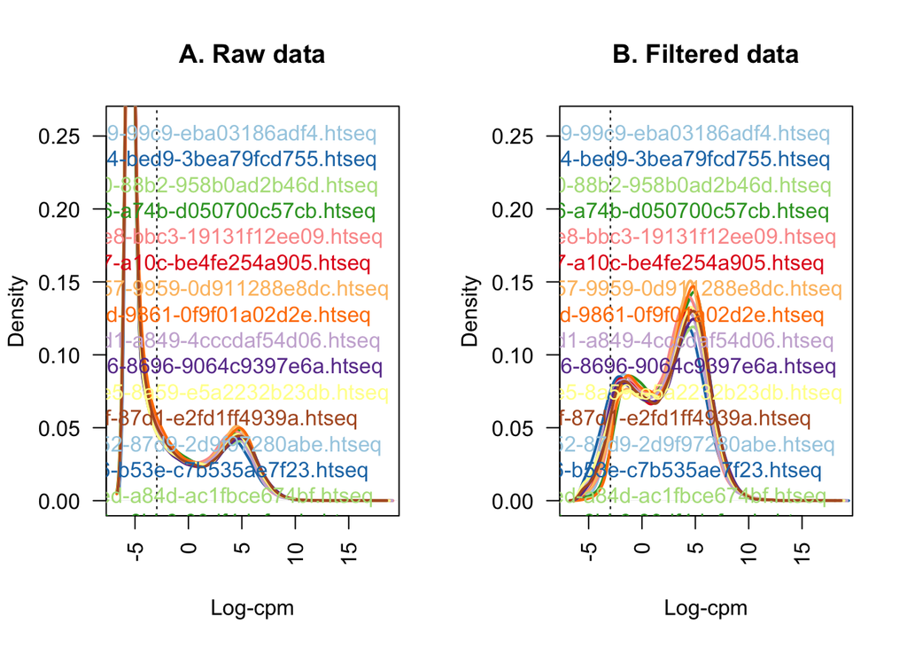

```r
par(mfrow=c(1,2))
plot(density(lcpm[,1]), col=col[1], lwd=2, ylim=c(0,0.26), las=2, main="", xlab="")
title(main="A. Raw data", xlab="Log-cpm")
abline(v=lcpm.cutoff, lty=3)
for (i in 2:nsamples){
den <- density(lcpm[,i])
lines(den$x, den$y, col=col[i], lwd=2)
}
legend("topright", samplenames, text.col=col, bty="n")
lcpm <- cpm(x, log=TRUE)
plot(density(lcpm[,1]), col=col[1], lwd=2, ylim=c(0,0.26), las=2, main="", xlab="")
title(main="B. Filtered data", xlab="Log-cpm")
abline(v=lcpm.cutoff, lty=3)
for (i in 2:nsamples){
den <- density(lcpm[,i])
lines(den$x, den$y, col=col[i], lwd=2)
}
legend("topright", samplenames, text.col=col, bty="n")
```

#Normalising gene expression distributions

```r
x <- calcNormFactors(x, method = "TMM")
x$samples$norm.factors
```

```
##  [1] 1.0267635 0.6807012 0.9816775 1.1920939 0.9007593 0.9387190 0.9507705
##  [8] 1.1785068 0.8262305 1.0400824 1.0090521 1.0529760 1.0054418 0.8627514
## [15] 1.0626060 1.0659112 1.1121083 1.0913743 1.0742490 1.1032624
```

#give a better visual representation of the effects of normalisation

```r
x2 <- x
x2$samples$norm.factors <- 1
x2$counts[,1] <- ceiling(x2$counts[,1]*0.05)
x2$counts[,2] <- x2$counts[,2]*5
```

#boxplot

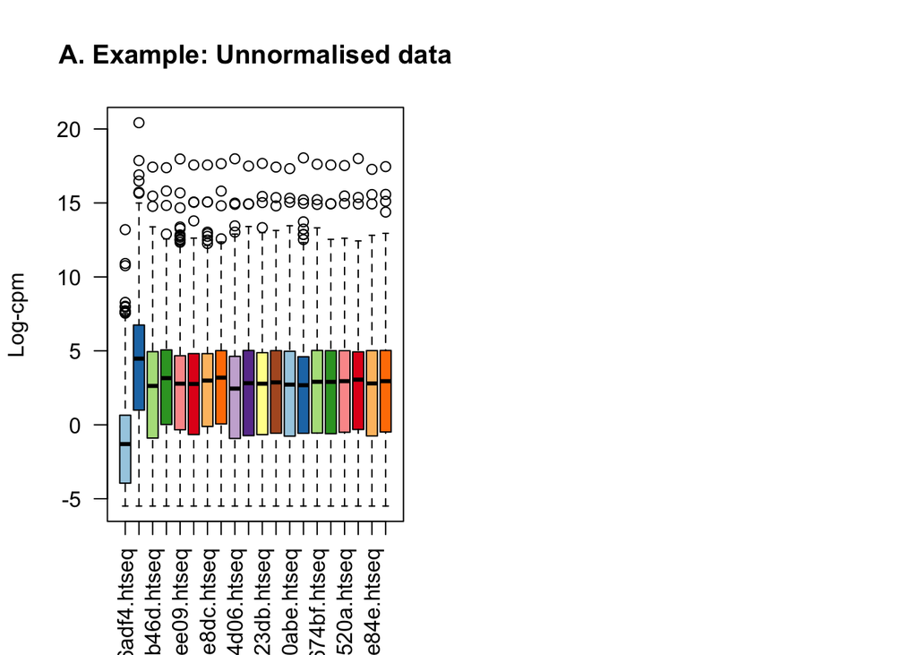

```r
par(mfrow=c(1,2))
lcpm <- cpm(x2, log=TRUE)
boxplot(lcpm, las=2, col=col, main="")
title(main="A. Example: Unnormalised data",ylab="Log-cpm")
```

```r
x2 <- calcNormFactors(x2)
x2$samples$norm.factors
```

```
##  [1] 0.06170912 3.45924167 1.04224629 1.31136601 0.96758531 1.01157173
##  [7] 1.04834965 1.23803719 0.90683828 1.10996762 1.06244594 1.14675868
## [13] 1.06897693 0.95817193 1.11883367 1.11743192 1.13850294 1.13784606
## [19] 1.11989289 1.18423559
```

#Boxplot expression for normalised data

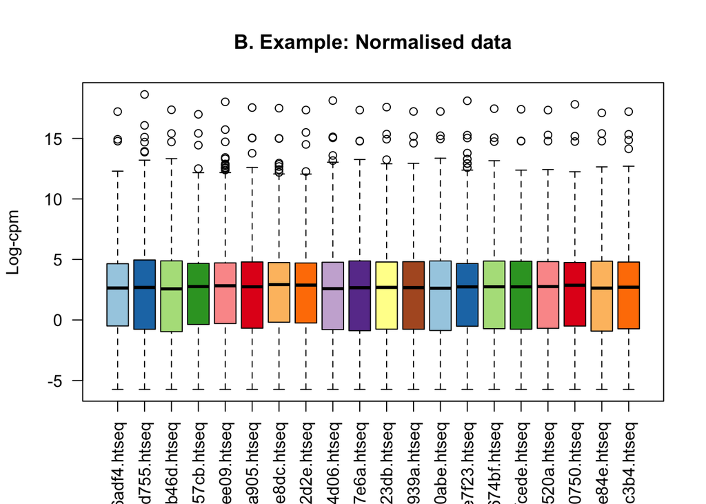

```r
lcpm <- cpm(x2, log=TRUE)
boxplot(lcpm, las=2, col=col, main="")
title(main="B. Example: Normalised data",ylab="Log-cpm")
```

#Unsupervised clustering of samples using multi-dimensional scaling (MDS) plot

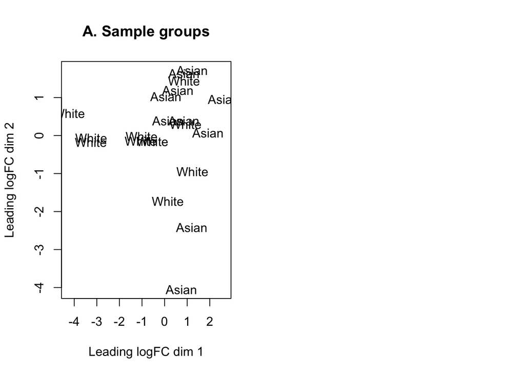

```r
lcpm <- cpm(x, log=TRUE)
par(mfrow=c(1,2))
col.group <- as.character(group)
col.group <- c("purple","orange")[group]
plotMDS(lcpm, labels=group, col=col.group)
title(main="A. Sample groups")
```

```r
#Glimma plot
glMDSPlot(lcpm, groups=group)
```

#Differential expression analysis

```r
#Creating a design matrix and contrasts
design <- model.matrix(~0+group)
colnames(design) <- gsub("group", "", colnames(design))
design
```

```
##    Asian White
## 1      0     1
## 2      0     1
## 3      0     1
## 4      0     1
## 5      0     1
## 6      0     1
## 7      0     1
## 8      0     1
## 9      0     1
## 10     0     1
## 11     1     0
## 12     1     0
## 13     1     0
## 14     1     0
## 15     1     0
## 16     1     0
## 17     1     0
## 18     1     0
## 19     1     0
## 20     1     0
## attr(,"assign")
## [1] 1 1
## attr(,"contrasts")
## attr(,"contrasts")$group
## [1] "contr.treatment"
```

#contrast matrix

```r
contr.matrix <- makeContrasts(
   WhitevsAsian = White-Asian,
   levels = colnames(design))
contr.matrix
```

```
##        Contrasts
## Levels  WhitevsAsian
##   Asian           -1
##   White            1
```

#Removing heteroscedascity from count data

```
## An object of class "EList"
## $genes
##           ENSEMBL   SYMBOL TXCHROM
## 2 ENSG00000000419     DPM1   chr20
## 3 ENSG00000000457    SCYL3    chr1
## 4 ENSG00000000460 C1orf112    chr1
## 5 ENSG00000000938      FGR    chr1
## 6 ENSG00000000971      CFH    chr1
## 20564 more rows ...
##
## $targets
##                                                                                        files
## 00b24800-9f29-47e9-99c9-eba03186adf4.htseq 00b24800-9f29-47e9-99c9-eba03186adf4.htseq.counts
## 1f226697-d1b4-4b04-bed9-3bea79fcd755.htseq 1f226697-d1b4-4b04-bed9-3bea79fcd755.htseq.counts
## 3fb92a97-b53b-4f00-88b2-958b0ad2b46d.htseq 3fb92a97-b53b-4f00-88b2-958b0ad2b46d.htseq.counts
## 7d7f57fe-a717-4d26-a74b-d050700c57cb.htseq 7d7f57fe-a717-4d26-a74b-d050700c57cb.htseq.counts
## 15b1a310-59b4-41e8-bbc3-19131f12ee09.htseq 15b1a310-59b4-41e8-bbc3-19131f12ee09.htseq.counts
##                                            group lib.size norm.factors
## 00b24800-9f29-47e9-99c9-eba03186adf4.htseq White 96348111    1.0267635
## 1f226697-d1b4-4b04-bed9-3bea79fcd755.htseq White 76156729    0.6807012
## 3fb92a97-b53b-4f00-88b2-958b0ad2b46d.htseq White 84012164    0.9816775
## 7d7f57fe-a717-4d26-a74b-d050700c57cb.htseq White 67370314    1.1920939
## 15b1a310-59b4-41e8-bbc3-19131f12ee09.htseq White 97032028    0.9007593
## 15 more rows ...
##
## $E
##                     Samples
## Tags                 00b24800-9f29-47e9-99c9-eba03186adf4.htseq
##   ENSG00000000419.11                                   4.221592
##   ENSG00000000457.12                                   4.842096
##   ENSG00000000460.15                                   4.333514
##   ENSG00000000938.11                                   2.237952
##   ENSG00000000971.14                                   5.217372
##                     Samples
## Tags                 1f226697-d1b4-4b04-bed9-3bea79fcd755.htseq
##   ENSG00000000419.11                                   4.714524
##   ENSG00000000457.12                                   4.079457
##   ENSG00000000460.15                                   1.931495
##   ENSG00000000938.11                                   2.309433
##   ENSG00000000971.14                                   7.971782
```

[output cut: 142 more lines]

```
## [1,] 2.0849954 1.9591621 2.161918 2.1131664 2.148653
## [2,] 1.8374120 1.6345901 1.998126 1.8944897 1.970342
## [3,] 1.3837022 1.2020671 1.586415 1.4463905 1.544077
## [4,] 0.9354153 0.8517059 1.042602 0.9667544 1.018632
## [5,] 1.8159181 1.6090936 1.982531 1.8725460 1.951221
## 20564 more rows ...
##
## $design
##   Asian White
## 1     0     1
## 2     0     1
## 3     0     1
## 4     0     1
## 5     0     1
## 15 more rows ...
```

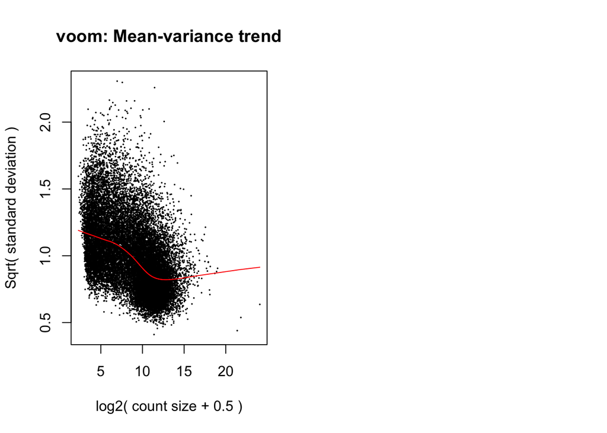

```r
par(mfrow=c(1,2))
v <- voom(x, design, plot=TRUE)
v
```

#Apply voom precision weights to data

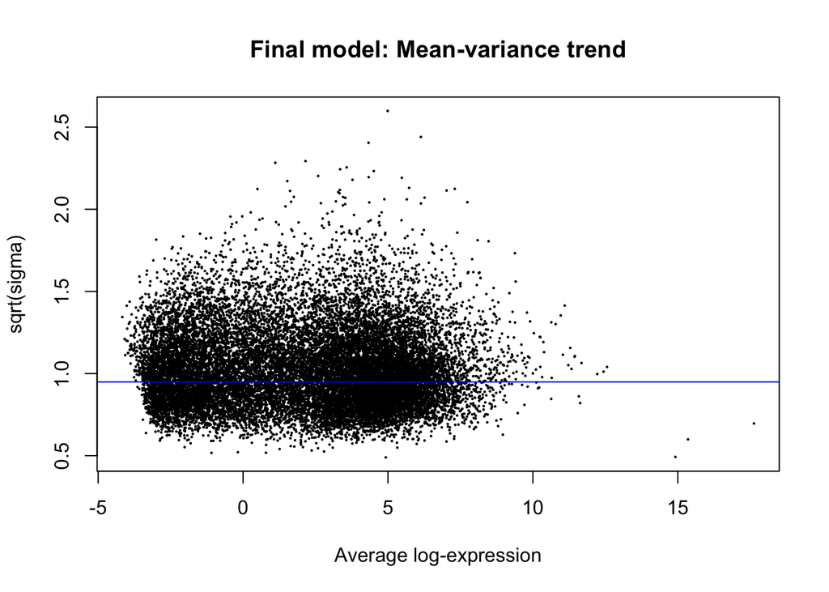

```r
vfit <- lmFit(v, design)
vfit <- contrasts.fit(vfit, contrasts=contr.matrix)
efit <- eBayes(vfit)
plotSA(efit, main="Final model: Mean-variance trend")
```

#Examining the number of DE genes

```r
summary(decideTests(efit))
```

```
##        WhitevsAsian
## Down              0
## NotSig        20568
## Up                1
```

```r
#set lfc = 1 and see the result
tfit <- treat(vfit, lfc=1)
dt <- decideTests(tfit)
summary(dt)
```

```
##        WhitevsAsian
## Down              0
## NotSig        20568
## Up                1
```

```r
#extract DE genes in multiple comparison
de.common <- which(dt[,1]!=0)
length(de.common)
```

```
## [1] 1
```

```r
head(tfit$genes$SYMBOL[de.common], n=20)
```

```
## [1] NA
```

#Make Venn Diagram

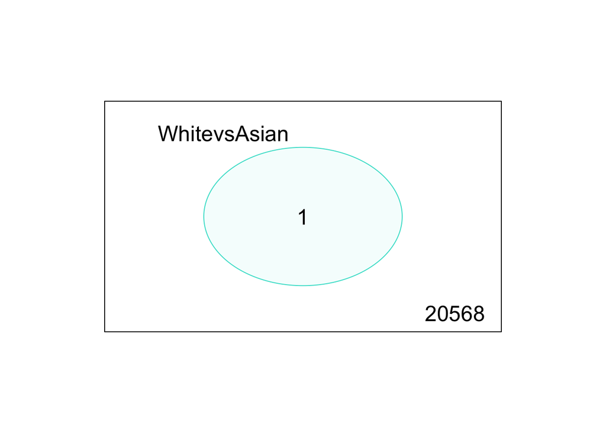

```r
vennDiagram(dt[,1], circle.col=c("turquoise", "salmon"))
```

#extract the result to a file

```r
write.fit(tfit, dt, file="results.txt")
```

#examnine the DE gene

```r
White.vs.Asian <- topTreat(tfit, coef=1, n=Inf)
head(White.vs.Asian)
```

```
##                            ENSEMBL  SYMBOL TXCHROM     logFC    AveExpr
## ENSG00000239830.1  ENSG00000239830    <NA>    <NA>  4.714020 -1.9506634
## ENSG00000151365.2  ENSG00000151365   THRSP   chr11  4.236134  2.1629444
## ENSG00000214128.9  ENSG00000214128 TMEM213    chr7  3.612507 -2.2510426
## ENSG00000134339.7  ENSG00000134339    SAA2   chr11  3.943810  0.1891389
## ENSG00000102243.11 ENSG00000102243   VGLL1    chrX  4.054301 -2.0462901
## ENSG00000267368.1  ENSG00000267368 UPK3BL1    <NA> -3.818062 -4.0255592
##                            t      P.Value   adj.P.Val
## ENSG00000239830.1   6.895313 3.153564e-07 0.006486566
## ENSG00000151365.2   3.796121 4.962109e-04 0.999999963
## ENSG00000214128.9   3.612796 7.716080e-04 0.999999963
## ENSG00000134339.7   3.594170 8.082238e-04 0.999999963
## ENSG00000102243.11  3.573727 8.496496e-04 0.999999963
## ENSG00000267368.1  -3.401872 1.282288e-03 0.999999963
```

#Useful graphical representations of differential expression results

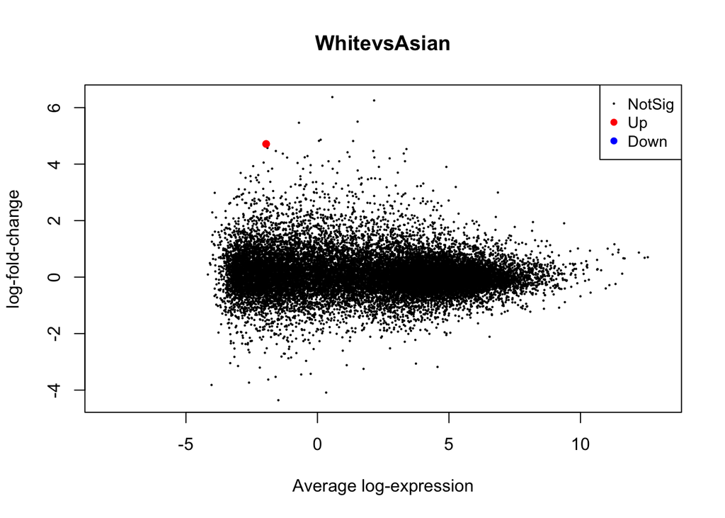

```r
plotMD(tfit, column=1, status=dt[,1], main=colnames(tfit)[1],
       xlim=c(-8,13))
```

#Make interactive mean-difference plot

```r
library(Glimma)
glMDPlot(tfit, coef=1, status=dt, main=colnames(tfit)[1],
         side.main="ENSEMBL", counts=lcpm, groups=group, launch=TRUE)
```

#Heatmap presentation of the DE gene

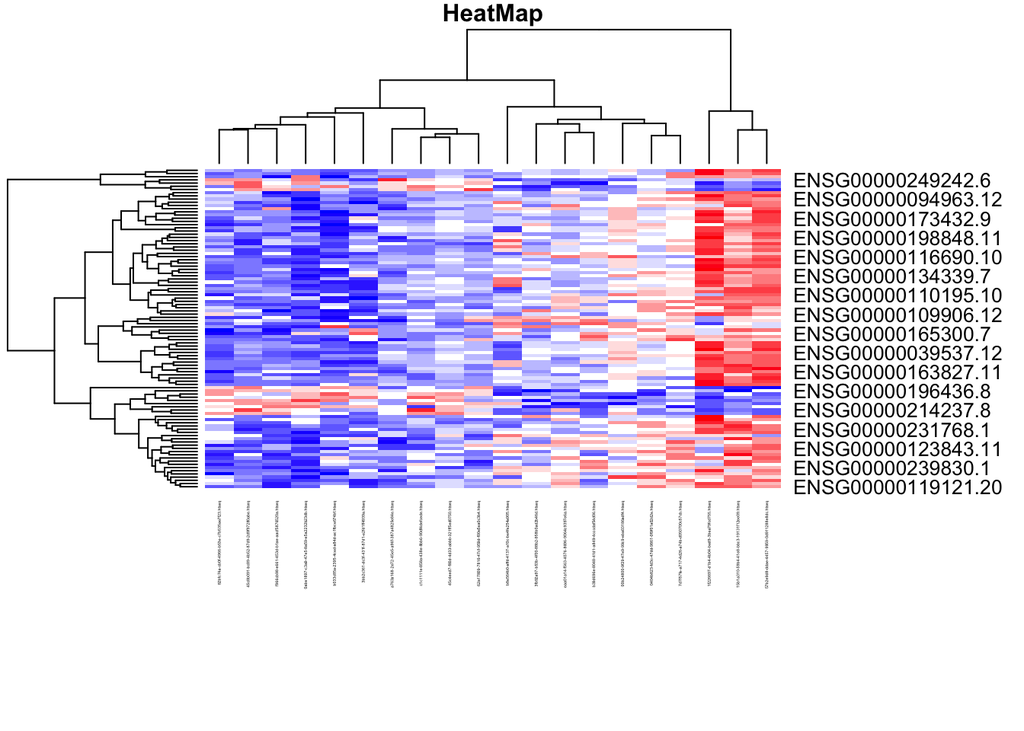

```r
library(gplots)
library(heatmap.plus)
White.vs.Asian.topgenes <- White.vs.Asian$ENSEMBL[1:100]
i <- which(v$genes$ENSEMBL %in% White.vs.Asian.topgenes)
mycol <- colorpanel(1000,"blue","white","red")
par(cex.main=0.8,mar=c(1,1,1,1))
heatmap.plus(lcpm[i,], col=bluered(20),cexRow=1,cexCol=0.2, margins = c(10,10), main = "HeatMap")
```